# Laboratorio 10 - Búsqueda Eficiente con PgVector

# P0. Dataset de Rostros

```python
import os
import glob
from pathlib import Path

import pandas as pd
import numpy as np
import matplotlib.pyplot as plt

DATASET_PATH = "/home/vssz/UTEC/5to/bd2/Lab11-DB2/lfw_funneled"
coleccion = []
for path in glob.iglob(os.path.join(DATASET_PATH, "**", "*.jpg"), recursive=True):
    person = Path(path).parent.name
    coleccion.append({"person": person, "path": path})

coleccion = pd.DataFrame(coleccion)
coleccion.head(10)
```

|  | person | path |
| --- | --- | --- |
| 0 | Muwafak_al-Ani | /home/vssz/UTEC/5to/bd2/Lab11-DB2/lfw_funneled... |
| 1 | Alex_Holmes | /home/vssz/UTEC/5to/bd2/Lab11-DB2/lfw_funneled... |
| 2 | Ian_Thorpe | /home/vssz/UTEC/5to/bd2/Lab11-DB2/lfw_funneled... |
| 3 | Ian_Thorpe | /home/vssz/UTEC/5to/bd2/Lab11-DB2/lfw_funneled... |
| 4 | Ian_Thorpe | /home/vssz/UTEC/5to/bd2/Lab11-DB2/lfw_funneled... |
| 5 | Ian_Thorpe | /home/vssz/UTEC/5to/bd2/Lab11-DB2/lfw_funneled... |
| 6 | Ian_Thorpe | /home/vssz/UTEC/5to/bd2/Lab11-DB2/lfw_funneled... |
| 7 | Ian_Thorpe | /home/vssz/UTEC/5to/bd2/Lab11-DB2/lfw_funneled... |
| 8 | Ian_Thorpe | /home/vssz/UTEC/5to/bd2/Lab11-DB2/lfw_funneled... |
| 9 | Ian_Thorpe | /home/vssz/UTEC/5to/bd2/Lab11-DB2/lfw_funneled... |

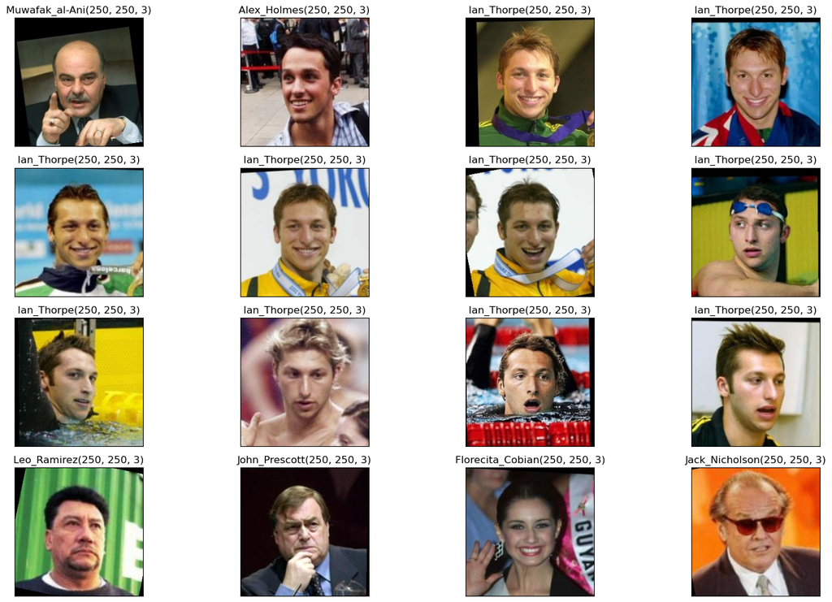

```python
def mostrarFotos(coleccion, posiciones):
    plt.figure(figsize=(16,10))
    i = 0
    for idx in posiciones:
        img = plt.imread(coleccion.path.iloc[idx])
        plt.subplot(4, 4, i+1)
        plt.imshow(img)
        plt.title(coleccion.person.iloc[idx]+str(img.shape))
        plt.xticks([])
        plt.yticks([])
        i += 1
    plt.tight_layout()
    plt.show()
posiciones = list(range(0, 16))
mostrarFotos(coleccion, posiciones)
```

# P1. Generar vectores característicos

Cada imagen se procesa con `face_recognition`. Si se detecta rostro, se extrae el primer embedding facial. Cada embedding tiene **128 dimensiones**.

## Crear tabla en PostgreSQL

Antes de guardar los embeddings, entramos en pgAdmin sobre nuestra base de datos creada:

```
CREATE EXTENSION IF NOT EXISTS vector;

CREATE TABLE face_embeddings (
    id SERIAL PRIMARY KEY,
    name TEXT,
    path TEXT,
    embedding VECTOR(128)
);
```

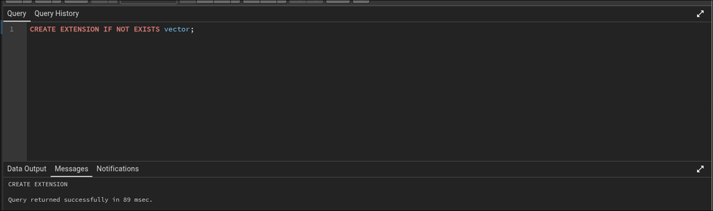

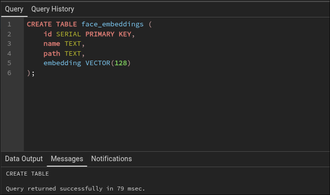

```python
import face_recognition
import psycopg2
from pgvector.psycopg2 import register_vector

DB_CONFIG = {
    "host": "127.0.0.1",
    "port": 5432,
    "database": "Lab11",
    "user": "postgres",
    "password": "123456"
}


def conectar_db():
    conn = psycopg2.connect(**DB_CONFIG)
    register_vector(conn)
    return conn

conn = conectar_db()
print("Conectado:", conn.status)
```

```
Conectado: 2
```

```python
def generate_face_embeddings(coleccion, n):
    resultados = []
    limite = min(n, len(coleccion))

    for i in range(limite):
        person = coleccion.iloc[i]["person"]
        filename = coleccion.iloc[i]["path"]

        try:
            image = face_recognition.load_image_file(filename)
            face_encodings = face_recognition.face_encodings(image)

            if face_encodings:
                embedding = face_encodings[0]

                resultados.append({
                    "name": person,
                    "path": filename,
                    "embedding": embedding
                })

                print(f"[OK] {i + 1}/{limite} - {person}")
            else:
                print(f"[SIN ROSTRO] {i + 1}/{limite} - {filename}")

        except Exception as e:
            print(f"[ERROR] {filename}: {e}")

    return resultados
```

```python
def guardar_embeddings_postgres(embeddings):
    conn = conectar_db()
    cur = conn.cursor()

    for item in embeddings:
        cur.execute(
            """
            INSERT INTO face_embeddings (name, path, embedding)
            VALUES (%s, %s, %s)
            """,
            (
                item["name"],
                item["path"],
                item["embedding"]
            )
        )

    conn.commit()
    cur.close()
    conn.close()

    print("Embeddings guardados correctamente en PostgreSQL.")
```

```python
N = len(coleccion)

embeddings = generate_face_embeddings(coleccion, N)
print("Cantidad de embeddings generados:", len(embeddings))

guardar_embeddings_postgres(embeddings)
```

[output not shown]

[output cut: 13180 more lines]

```
[OK] 13221/13233 - Wang_Hailan
[OK] 13222/13233 - Michael_Chiklis
[OK] 13223/13233 - Michael_Chiklis
[OK] 13224/13233 - Michael_Chiklis
[OK] 13225/13233 - Michael_Chiklis
[OK] 13226/13233 - Michael_Chiklis
[OK] 13227/13233 - Jean-Francois_Pontal
[OK] 13228/13233 - Jean-Francois_Pontal
[OK] 13229/13233 - Jean-Francois_Pontal
[OK] 13230/13233 - Mark_Rosenbaum
[OK] 13231/13233 - Michael_Fitzgerald
[OK] 13232/13233 - Earl_Counter
[OK] 13233/13233 - Infanta_Cristina
Cantidad de embeddings generados: 13176
Embeddings guardados correctamente en PostgreSQL.
```

## Verificamos los embeddings guardados

```python
conn = conectar_db()
cur = conn.cursor()

cur.execute("SELECT COUNT(*) FROM face_embeddings;")
print("Total de embeddings en PostgreSQL:", cur.fetchone()[0])

cur.execute("SELECT id, name, path, vector_dims(embedding) FROM face_embeddings LIMIT 10;")
for row in cur.fetchall():
    print(row)

cur.close()
conn.close()
```

```
Total de embeddings en PostgreSQL: 13176
(1, 'Muwafak_al-Ani', '/home/vssz/UTEC/5to/bd2/Lab11-DB2/lfw_funneled/Muwafak_al-Ani/Muwafak_al-Ani_0001.jpg', 128)
(2, 'Alex_Holmes', '/home/vssz/UTEC/5to/bd2/Lab11-DB2/lfw_funneled/Alex_Holmes/Alex_Holmes_0001.jpg', 128)
(3, 'Ian_Thorpe', '/home/vssz/UTEC/5to/bd2/Lab11-DB2/lfw_funneled/Ian_Thorpe/Ian_Thorpe_0005.jpg', 128)
(4, 'Ian_Thorpe', '/home/vssz/UTEC/5to/bd2/Lab11-DB2/lfw_funneled/Ian_Thorpe/Ian_Thorpe_0004.jpg', 128)
(5, 'Ian_Thorpe', '/home/vssz/UTEC/5to/bd2/Lab11-DB2/lfw_funneled/Ian_Thorpe/Ian_Thorpe_0008.jpg', 128)
(6, 'Ian_Thorpe', '/home/vssz/UTEC/5to/bd2/Lab11-DB2/lfw_funneled/Ian_Thorpe/Ian_Thorpe_0003.jpg', 128)
(7, 'Ian_Thorpe', '/home/vssz/UTEC/5to/bd2/Lab11-DB2/lfw_funneled/Ian_Thorpe/Ian_Thorpe_0006.jpg', 128)
(8, 'Ian_Thorpe', '/home/vssz/UTEC/5to/bd2/Lab11-DB2/lfw_funneled/Ian_Thorpe/Ian_Thorpe_0002.jpg', 128)
(9, 'Ian_Thorpe', '/home/vssz/UTEC/5to/bd2/Lab11-DB2/lfw_funneled/Ian_Thorpe/Ian_Thorpe_0007.jpg', 128)
(10, 'Ian_Thorpe', '/home/vssz/UTEC/5to/bd2/Lab11-DB2/lfw_funneled/Ian_Thorpe/Ian_Thorpe_0010.jpg', 128)
```

# P2. Búsqueda kNN Lineal

En esta parte no usamos índices. La consulta compara el embedding de entrada con todos los embeddings guardados en la tabla.

Se usan dos distancias:

- Distancia euclidiana: `<->`
- Distancia coseno: `<=>`

```python
import os
import time
import face_recognition

QUERY_IMAGE = "/home/vssz/UTEC/5to/bd2/Lab11-DB2/consulta.jpeg"

def obtener_embedding_consulta(path):
    image = face_recognition.load_image_file(path)
    encs = face_recognition.face_encodings(image)
    if not encs:
        raise ValueError(f"No se detectó rostro en {path}")
    return encs[0]


def embedding_to_pgvector(embedding):
    return "[" + ",".join(map(str, embedding.tolist())) + "]"


def knn_lineal_euclidiana(query_embedding, k=5):
    conn = conectar_db()
    cur = conn.cursor()

    query_vector = embedding_to_pgvector(query_embedding)

    start = time.perf_counter()

    cur.execute(
        """
        SELECT
            id,
            name,
            path,
            embedding <-> %s::vector AS distance
        FROM face_embeddings
        ORDER BY embedding <-> %s::vector
        LIMIT %s;
        """,
        (query_vector, query_vector, k)
    )

    resultados = cur.fetchall()
    end = time.perf_counter()

    cur.close()
    conn.close()

    return resultados, end - start


def knn_lineal_coseno(query_embedding, k=5):
    conn = conectar_db()
    cur = conn.cursor()

    query_vector = embedding_to_pgvector(query_embedding)

    start = time.perf_counter()

    cur.execute(
        """
        SELECT
            id,
            name,
            path,
            embedding <=> %s::vector AS distance
        FROM face_embeddings
        ORDER BY embedding <=> %s::vector
        LIMIT %s;
        """,
        (query_vector, query_vector, k)
    )

    resultados = cur.fetchall()
    end = time.perf_counter()

    cur.close()
    conn.close()

    return resultados, end - start
```

```python
K = 5

query_embedding = obtener_embedding_consulta(QUERY_IMAGE)

resultados_euclidiana, tiempo_euclidiana = knn_lineal_euclidiana(query_embedding, K)
resultados_coseno, tiempo_coseno = knn_lineal_coseno(query_embedding, K)

print("===== RESULTADOS KNN LINEAL - DISTANCIA EUCLIDIANA =====")
for r in resultados_euclidiana:
    print(f"ID: {r[0]} | Nombre: {r[1]} | Distancia: {r[3]:.6f} | Path: {r[2]}")

print(f"Tiempo euclidiana: {tiempo_euclidiana:.6f} segundos")

print("\n===== RESULTADOS KNN LINEAL - DISTANCIA COSENO =====")
for r in resultados_coseno:
    print(f"ID: {r[0]} | Nombre: {r[1]} | Distancia: {r[3]:.6f} | Path: {r[2]}")

print(f"Tiempo coseno: {tiempo_coseno:.6f} segundos")
```

```
===== RESULTADOS KNN LINEAL - DISTANCIA EUCLIDIANA =====
ID: 4470 | Nombre: Alessandra_Cerna | Distancia: 0.531149 | Path: /home/vssz/UTEC/5to/bd2/Lab11-DB2/lfw_funneled/Alessandra_Cerna/Alessandra_Cerna_0001.jpg
ID: 12523 | Nombre: Yasein_Taher | Distancia: 0.550054 | Path: /home/vssz/UTEC/5to/bd2/Lab11-DB2/lfw_funneled/Yasein_Taher/Yasein_Taher_0001.jpg
ID: 2727 | Nombre: Leon_Lai | Distancia: 0.558489 | Path: /home/vssz/UTEC/5to/bd2/Lab11-DB2/lfw_funneled/Leon_Lai/Leon_Lai_0001.jpg
ID: 7918 | Nombre: Juan_Carlos_Ortega | Distancia: 0.569526 | Path: /home/vssz/UTEC/5to/bd2/Lab11-DB2/lfw_funneled/Juan_Carlos_Ortega/Juan_Carlos_Ortega_0001.jpg
ID: 3653 | Nombre: Aung_San_Suu_Kyi | Distancia: 0.576949 | Path: /home/vssz/UTEC/5to/bd2/Lab11-DB2/lfw_funneled/Aung_San_Suu_Kyi/Aung_San_Suu_Kyi_0001.jpg
Tiempo euclidiana: 0.003930 segundos

===== RESULTADOS KNN LINEAL - DISTANCIA COSENO =====
ID: 4470 | Nombre: Alessandra_Cerna | Distancia: 0.071946 | Path: /home/vssz/UTEC/5to/bd2/Lab11-DB2/lfw_funneled/Alessandra_Cerna/Alessandra_Cerna_0001.jpg
ID: 7918 | Nombre: Juan_Carlos_Ortega | Distancia: 0.074295 | Path: /home/vssz/UTEC/5to/bd2/Lab11-DB2/lfw_funneled/Juan_Carlos_Ortega/Juan_Carlos_Ortega_0001.jpg
ID: 2727 | Nombre: Leon_Lai | Distancia: 0.078747 | Path: /home/vssz/UTEC/5to/bd2/Lab11-DB2/lfw_funneled/Leon_Lai/Leon_Lai_0001.jpg
ID: 12523 | Nombre: Yasein_Taher | Distancia: 0.080535 | Path: /home/vssz/UTEC/5to/bd2/Lab11-DB2/lfw_funneled/Yasein_Taher/Yasein_Taher_0001.jpg
ID: 3653 | Nombre: Aung_San_Suu_Kyi | Distancia: 0.085507 | Path: /home/vssz/UTEC/5to/bd2/Lab11-DB2/lfw_funneled/Aung_San_Suu_Kyi/Aung_San_Suu_Kyi_0001.jpg
Tiempo coseno: 0.003717 segundos
```

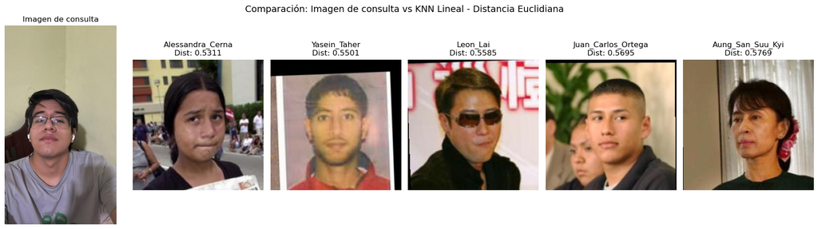

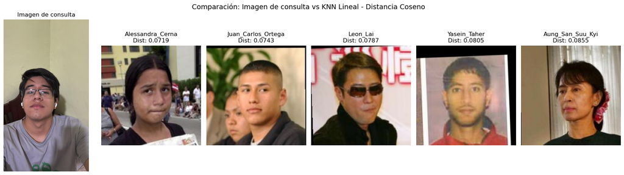

```python
def mostrar_consulta_y_resultados(query_image, resultados, titulo):
    total_imgs = len(resultados) + 1

    plt.figure(figsize=(18, 5))

    # Imagen de consulta
    img_query = plt.imread(query_image)

    plt.subplot(1, total_imgs, 1)
    plt.imshow(img_query)
    plt.title("Imagen de consulta")
    plt.axis("off")

    # Resultados kNN
    for i, r in enumerate(resultados):
        img_path = r[2]
        name = r[1]
        distance = r[3]

        img = plt.imread(img_path)

        plt.subplot(1, total_imgs, i + 2)
        plt.imshow(img)
        plt.title(f"{name}\nDist: {distance:.4f}")
        plt.axis("off")

    plt.suptitle(titulo, fontsize=14)
    plt.tight_layout()
    plt.show()

mostrar_consulta_y_resultados(
    QUERY_IMAGE,
    resultados_euclidiana,
    "Comparación: Imagen de consulta vs KNN Lineal - Distancia Euclidiana"
)

mostrar_consulta_y_resultados(
    QUERY_IMAGE,
    resultados_coseno,
    "Comparación: Imagen de consulta vs KNN Lineal - Distancia Coseno"
)
```

## EXPLAIN ANALYZE

```python
def explain_analyze_knn(query_embedding, operador="<->", k=5):
    conn = conectar_db()
    cur = conn.cursor()

    query_vector = embedding_to_pgvector(query_embedding)

    cur.execute(
        f"""
        EXPLAIN ANALYZE
        SELECT
            id,
            name,
            path,
            embedding {operador} %s::vector AS distance
        FROM face_embeddings
        ORDER BY embedding {operador} %s::vector
        LIMIT %s;
        """,
        (
            query_vector,
            query_vector,
            k
        )
    )

    plan = cur.fetchall()

    cur.close()
    conn.close()

    for row in plan:
        print(row[0])
```

```python
print("===== EXPLAIN ANALYZE EUCLIDIANA =====")
explain_analyze_knn(query_embedding, "<->", 5)

print("\n===== EXPLAIN ANALYZE COSENO =====")
explain_analyze_knn(query_embedding, "<=>", 5)
```

```
===== EXPLAIN ANALYZE EUCLIDIANA =====
Limit  (cost=1482.55..1482.56 rows=5 width=111) (actual time=6.787..6.791 rows=5 loops=1)
  ->  Sort  (cost=1482.55..1515.49 rows=13176 width=111) (actual time=6.786..6.787 rows=5 loops=1)
        Sort Key: ((embedding <-> '[-0.034972206,0.11529441,0.051431753,-0.02243278,-0.054212082,0.028898228,-0.074783534,-0.1147949,0.1254508,-0.13373904,0.20919612,0.03058547,-0.15566534,-0.02057812,-0.027379349,0.1127178,-0.1513519,-0.097122796,-0.062133476,0.031431187,-0.0070168707,-0.08845806,0…
        Sort Method: top-N heapsort  Memory: 26kB
        ->  Seq Scan on face_embeddings  (cost=0.00..1263.70 rows=13176 width=111) (actual time=0.008..5.234 rows=13176 loops=1)
Planning Time: 0.314 ms
Execution Time: 6.822 ms

===== EXPLAIN ANALYZE COSENO =====
Limit  (cost=1482.55..1482.56 rows=5 width=111) (actual time=7.043..7.044 rows=5 loops=1)
  ->  Sort  (cost=1482.55..1515.49 rows=13176 width=111) (actual time=7.041..7.042 rows=5 loops=1)
        Sort Key: ((embedding <=> '[-0.034972206,0.11529441,0.051431753,-0.02243278,-0.054212082,0.028898228,-0.074783534,-0.1147949,0.1254508,-0.13373904,0.20919612,0.03058547,-0.15566534,-0.02057812,-0.027379349,0.1127178,-0.1513519,-0.097122796,-0.062133476,0.031431187,-0.0070168707,-0.08845806,0…
        Sort Method: top-N heapsort  Memory: 26kB
        ->  Seq Scan on face_embeddings  (cost=0.00..1263.70 rows=13176 width=111) (actual time=0.008..5.507 rows=13176 loops=1)
Planning Time: 0.305 ms
Execution Time: 7.072 ms
```

## Análisis de resultados P2

### Tiempos medidos

Tiempos reportados por `EXPLAIN ANALYZE` (incluye overhead del planner):

| Distancia | Execution Time | Planning Time |
| --- | --- | --- |
| Euclidiana | 6.822 ms | 0.314 ms |
| Coseno | 7.072 ms | 0.305 ms |

### ¿Qué confirma el EXPLAIN ANALYZE?

El plan de ejecución muestra:

- **`Seq Scan on face_embeddings (rows=13176)`** -> PostgreSQL recorre las 13,176 filas una por una (búsqueda lineal sin índice).
- **`Sort Method: top-N heapsort (Memory: 26kB)`** -> ordena por distancia y se queda solo con los k=5 más cercanos.
- **`cost=0.00..1263.70`** -> el costo estimado refleja un escaneo completo de la tabla.

### Comparación de los k=5 vecinos más cercanos

| Rank | Euclidiana `<->` | Distancia | Coseno `<=>` | Distancia |
| --- | --- | --- | --- | --- |
| 1 | Alessandra_Cerna | 0.531149 | Alessandra_Cerna | 0.071946 |
| 2 | Yasein_Taher | 0.550054 | Juan_Carlos_Ortega | 0.074295 |
| 3 | Leon_Lai | 0.558489 | Leon_Lai | 0.078747 |
| 4 | Juan_Carlos_Ortega | 0.569526 | Yasein_Taher | 0.080535 |
| 5 | Aung_San_Suu_Kyi | 0.576949 | Aung_San_Suu_Kyi | 0.085507 |

### ¿Con ambas distancias se obtiene el mismo resultado?

Sí. Las dos distancias recuperan el mismo conjunto de 5 personas y el top-1 coincide (Alessandra_Cerna). La única diferencia es que las posiciones 2 y 4 se intercambian entre Yasein_Taher y Juan_Carlos_Ortega.

### Conclusión

Para reconocimiento facial con embeddings de `face_recognition`, ambas  
distancias son **equivalentes en la práctica**: identifican al mismo  
vecino más cercano y recuperan el mismo conjunto de personas similares.  
La elección entre `<->` o `<=>` suele depender del índice que se usará después o de si los vectores están normalizados.

## P3. Búsqueda kNN usando PgVector

```python
def ejecutar_sql(sql):
    conn = conectar_db()
    cur = conn.cursor()
    cur.execute(sql)
    conn.commit()
    cur.close()
    conn.close()
    print("SQL ejecutado correctamente.")
```

```python
sql_ivf_l2 = """
DROP INDEX IF EXISTS face_embedding_ivfflat_l2_idx;

CREATE INDEX face_embedding_ivfflat_l2_idx
ON face_embeddings
USING ivfflat (embedding vector_l2_ops)
WITH (lists = 100);
"""

ejecutar_sql(sql_ivf_l2)
```

```
SQL ejecutado correctamente.
```

```python
ejecutar_sql("ANALYZE face_embeddings;")
```

```
SQL ejecutado correctamente.
```

## IVFFLat

```python
print("===== EXPLAIN ANALYZE EUCLIDIANA =====")
explain_analyze_knn(query_embedding, "<->", 5)

print("\n===== EXPLAIN ANALYZE COSENO =====")
explain_analyze_knn(query_embedding, "<=>", 5)
```

```
===== EXPLAIN ANALYZE EUCLIDIANA =====
Limit  (cost=24.29..26.93 rows=5 width=111) (actual time=0.071..0.086 rows=5 loops=1)
  ->  Index Scan using face_embedding_ivfflat_l2_idx on face_embeddings  (cost=24.29..6989.52 rows=13176 width=111) (actual time=0.071..0.085 rows=5 loops=1)
        Order By: (embedding <-> '[-0.034972206,0.11529441,0.051431753,-0.02243278,-0.054212082,0.028898228,-0.074783534,-0.1147949,0.1254508,-0.13373904,0.20919612,0.03058547,-0.15566534,-0.02057812,-0.027379349,0.1127178,-0.1513519,-0.097122796,-0.062133476,0.031431187,-0.0070168707,-0.08845806,0.…
Planning Time: 0.362 ms
Execution Time: 0.112 ms

===== EXPLAIN ANALYZE COSENO =====
Limit  (cost=1482.55..1482.56 rows=5 width=111) (actual time=6.541..6.543 rows=5 loops=1)
  ->  Sort  (cost=1482.55..1515.49 rows=13176 width=111) (actual time=6.540..6.540 rows=5 loops=1)
        Sort Key: ((embedding <=> '[-0.034972206,0.11529441,0.051431753,-0.02243278,-0.054212082,0.028898228,-0.074783534,-0.1147949,0.1254508,-0.13373904,0.20919612,0.03058547,-0.15566534,-0.02057812,-0.027379349,0.1127178,-0.1513519,-0.097122796,-0.062133476,0.031431187,-0.0070168707,-0.08845806,0…
        Sort Method: top-N heapsort  Memory: 26kB
        ->  Seq Scan on face_embeddings  (cost=0.00..1263.70 rows=13176 width=111) (actual time=0.008..4.974 rows=13176 loops=1)
Planning Time: 0.357 ms
Execution Time: 6.585 ms
```

```python
def knn_ivfflat_euclidiana(query_embedding, k=5, probes=10):
    conn = conectar_db()
    cur = conn.cursor()

    query_vector = embedding_to_pgvector(query_embedding)

    cur.execute(f"SET ivfflat.probes = {probes};")

    start = time.perf_counter()

    cur.execute(
        """
        SELECT
            id,
            name,
            path,
            embedding <-> %s::vector AS distance
        FROM face_embeddings
        ORDER BY embedding <-> %s::vector
        LIMIT %s;
        """,
        (query_vector, query_vector, k)
    )

    resultados = cur.fetchall()
    end = time.perf_counter()

    cur.close()
    conn.close()

    return resultados, end - start
```

```python
resultados_ivf_l2, tiempo_ivf_l2 = knn_ivfflat_euclidiana(query_embedding, k=5, probes=10)

print("===== KNN IVFFLAT - EUCLIDIANA =====")
for r in resultados_ivf_l2:
    print(f"ID: {r[0]} | Nombre: {r[1]} | Distancia: {r[3]:.6f} | Path: {r[2]}")

print(f"Tiempo IVFFlat euclidiana: {tiempo_ivf_l2:.6f} segundos")
```

```
===== KNN IVFFLAT - EUCLIDIANA =====
ID: 4470 | Nombre: Alessandra_Cerna | Distancia: 0.531149 | Path: /home/vssz/UTEC/5to/bd2/Lab11-DB2/lfw_funneled/Alessandra_Cerna/Alessandra_Cerna_0001.jpg
ID: 12523 | Nombre: Yasein_Taher | Distancia: 0.550054 | Path: /home/vssz/UTEC/5to/bd2/Lab11-DB2/lfw_funneled/Yasein_Taher/Yasein_Taher_0001.jpg
ID: 2727 | Nombre: Leon_Lai | Distancia: 0.558489 | Path: /home/vssz/UTEC/5to/bd2/Lab11-DB2/lfw_funneled/Leon_Lai/Leon_Lai_0001.jpg
ID: 7918 | Nombre: Juan_Carlos_Ortega | Distancia: 0.569526 | Path: /home/vssz/UTEC/5to/bd2/Lab11-DB2/lfw_funneled/Juan_Carlos_Ortega/Juan_Carlos_Ortega_0001.jpg
ID: 12008 | Nombre: Guillermo_Canas | Distancia: 0.577200 | Path: /home/vssz/UTEC/5to/bd2/Lab11-DB2/lfw_funneled/Guillermo_Canas/Guillermo_Canas_0002.jpg
Tiempo IVFFlat euclidiana: 0.001769 segundos
```

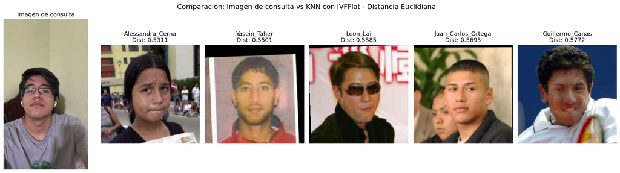

```python
mostrar_consulta_y_resultados(
    QUERY_IMAGE,
    resultados_ivf_l2,
    "Comparación: Imagen de consulta vs KNN con IVFFlat - Distancia Euclidiana"
)
```

EXPLAIN ANALYZE para IVFFlat euclidiano

```python
def explain_analyze_ivfflat(query_embedding, operador="<->", k=5, probes=10):
    conn = conectar_db()
    cur = conn.cursor()

    query_vector = embedding_to_pgvector(query_embedding)

    cur.execute(f"SET ivfflat.probes = {probes};")

    cur.execute(
        f"""
        EXPLAIN ANALYZE
        SELECT
            id,
            name,
            path,
            embedding {operador} %s::vector AS distance
        FROM face_embeddings
        ORDER BY embedding {operador} %s::vector
        LIMIT %s;
        """,
        (
            query_vector,
            query_vector,
            k
        )
    )

    plan = cur.fetchall()

    cur.close()
    conn.close()

    for row in plan:
        print(row[0])
```

```python
print("===== EXPLAIN ANALYZE IVFFLAT EUCLIDIANA =====")
explain_analyze_ivfflat(query_embedding, "<->", k=5, probes=10)
```

```
===== EXPLAIN ANALYZE IVFFLAT EUCLIDIANA =====
Limit  (cost=242.88..245.44 rows=5 width=111) (actual time=0.520..0.538 rows=5 loops=1)
  ->  Index Scan using face_embedding_ivfflat_l2_idx on face_embeddings  (cost=242.88..6989.52 rows=13176 width=111) (actual time=0.519..0.537 rows=5 loops=1)
        Order By: (embedding <-> '[-0.034972206,0.11529441,0.051431753,-0.02243278,-0.054212082,0.028898228,-0.074783534,-0.1147949,0.1254508,-0.13373904,0.20919612,0.03058547,-0.15566534,-0.02057812,-0.027379349,0.1127178,-0.1513519,-0.097122796,-0.062133476,0.031431187,-0.0070168707,-0.08845806,0.…
Planning Time: 0.372 ms
Execution Time: 0.576 ms
```

4. Crear índice IVFFlat coseno

```python
sql_ivf_cosine = """
DROP INDEX IF EXISTS face_embedding_ivfflat_cosine_idx;

CREATE INDEX face_embedding_ivfflat_cosine_idx
ON face_embeddings
USING ivfflat (embedding vector_cosine_ops)
WITH (lists = 100);
"""

ejecutar_sql(sql_ivf_cosine)
ejecutar_sql("ANALYZE face_embeddings;")
```

```
SQL ejecutado correctamente.
SQL ejecutado correctamente.
```

5. Función kNN IVFFlat coseno

```python
def knn_ivfflat_coseno(query_embedding, k=5, probes=10):
    conn = conectar_db()
    cur = conn.cursor()

    query_vector = embedding_to_pgvector(query_embedding)

    cur.execute(f"SET ivfflat.probes = {probes};")

    start = time.perf_counter()

    cur.execute(
        """
        SELECT
            id,
            name,
            path,
            embedding <=> %s::vector AS distance
        FROM face_embeddings
        ORDER BY embedding <=> %s::vector
        LIMIT %s;
        """,
        (query_vector, query_vector, k)
    )

    resultados = cur.fetchall()
    end = time.perf_counter()

    cur.close()
    conn.close()

    return resultados, end - start
```

```python
resultados_ivf_coseno, tiempo_ivf_coseno = knn_ivfflat_coseno(query_embedding, k=5, probes=10)

print("===== KNN IVFFLAT - COSENO =====")
for r in resultados_ivf_coseno:
    print(f"ID: {r[0]} | Nombre: {r[1]} | Distancia: {r[3]:.6f} | Path: {r[2]}")

print(f"Tiempo IVFFlat coseno: {tiempo_ivf_coseno:.6f} segundos")
```

```
===== KNN IVFFLAT - COSENO =====
ID: 4470 | Nombre: Alessandra_Cerna | Distancia: 0.071946 | Path: /home/vssz/UTEC/5to/bd2/Lab11-DB2/lfw_funneled/Alessandra_Cerna/Alessandra_Cerna_0001.jpg
ID: 7918 | Nombre: Juan_Carlos_Ortega | Distancia: 0.074295 | Path: /home/vssz/UTEC/5to/bd2/Lab11-DB2/lfw_funneled/Juan_Carlos_Ortega/Juan_Carlos_Ortega_0001.jpg
ID: 2727 | Nombre: Leon_Lai | Distancia: 0.078747 | Path: /home/vssz/UTEC/5to/bd2/Lab11-DB2/lfw_funneled/Leon_Lai/Leon_Lai_0001.jpg
ID: 12523 | Nombre: Yasein_Taher | Distancia: 0.080535 | Path: /home/vssz/UTEC/5to/bd2/Lab11-DB2/lfw_funneled/Yasein_Taher/Yasein_Taher_0001.jpg
ID: 3653 | Nombre: Aung_San_Suu_Kyi | Distancia: 0.085507 | Path: /home/vssz/UTEC/5to/bd2/Lab11-DB2/lfw_funneled/Aung_San_Suu_Kyi/Aung_San_Suu_Kyi_0001.jpg
Tiempo IVFFlat coseno: 0.001690 segundos
```

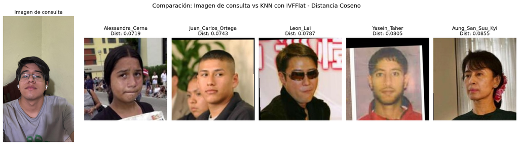

```python
mostrar_consulta_y_resultados(
    QUERY_IMAGE,
    resultados_ivf_coseno,
    "Comparación: Imagen de consulta vs KNN con IVFFlat - Distancia Coseno"
)
```

```python
print("===== EXPLAIN ANALYZE IVFFLAT COSENO =====")
explain_analyze_ivfflat(query_embedding, "<=>", k=5, probes=10)
```

```
===== EXPLAIN ANALYZE IVFFLAT COSENO =====
Limit  (cost=242.63..245.19 rows=5 width=111) (actual time=1.128..1.157 rows=5 loops=1)
  ->  Index Scan using face_embedding_ivfflat_cosine_idx on face_embeddings  (cost=242.63..6987.02 rows=13176 width=111) (actual time=1.127..1.155 rows=5 loops=1)
        Order By: (embedding <=> '[-0.034972206,0.11529441,0.051431753,-0.02243278,-0.054212082,0.028898228,-0.074783534,-0.1147949,0.1254508,-0.13373904,0.20919612,0.03058547,-0.15566534,-0.02057812,-0.027379349,0.1127178,-0.1513519,-0.097122796,-0.062133476,0.031431187,-0.0070168707,-0.08845806,0.…
Planning Time: 0.531 ms
Execution Time: 1.208 ms
```

### Comparación lineal vs IVFFlat

| Método | Distancia | Plan de ejecución | Execution Time |
| --- | --- | --- | --- |
| Lineal (P2) | Euclidiana `<->` | `Seq Scan on face_embeddings` | **6.822 ms** |
| Lineal (P2) | Coseno `<=>` | `Seq Scan on face_embeddings` | **7.072 ms** |

[output not shown]

### Speedup obtenido con IVFFlat

| Distancia | Tiempo lineal | Tiempo IVFFlat | Speedup |  
|---|---|---|---|  
| Euclidiana | 6.822 ms | 0.576 ms | **≈ 11.85x** |  
| Coseno | 7.072 ms | 1.208 ms | **≈ 5.85x** |

### Calidad de los resultados (Recall@5)

IVFFlat es una búsqueda **aproximada**: divide los 13,176 vectores en `lists = 100` clústeres y solo explora los `probes = 10` más cercanos  
al vector de consulta. Esto puede provocar que algún vecino real  
quede fuera de los clústeres explorados.

| Distancia | Recall@5 |
| --- | --- |
| IVFFlat Euclidiana | 80% (4 de 5 coinciden con la búsqueda lineal) |
| IVFFlat Coseno | 100% (los 5 coinciden con la búsqueda lineal) |

El recall puede subirse aumentando `ivfflat.probes` (más clústeres  
explorados → más precisión, pero más tiempo de búsqueda).

### Análisis de los resultados respecto a la búsqueda lineal

1. **El plan de ejecución cambia de `Seq Scan` a `Index Scan`**, lo cual  
confirma que pgvector aprovecha correctamente los índices IVFFlat.  
2. **La búsqueda con índice es entre 5x y 12x más rápida** que la lineal  
sobre 13k vectores. La mejora sería mucho mayor con millones de  
vectores, donde el `Seq Scan` se vuelve impracticable.  
3. **El costo a pagar es una pérdida de precisión** (recall): en  
euclidiana se perdió 1 vecino del top-5 (80% recall). Esto es  
el clásico trade-off velocidad vs precisión de los índices  
aproximados (ANN).  
4. **Coseno mantuvo el 100% de recall** en este caso particular, pero  
esto puede variar según el vector de consulta — no es una garantía.

### Conclusión

IVFFlat acelera significativamente la búsqueda KNN (5x–12x) a cambio  
de una pequeña pérdida de precisión. Para aplicaciones de reconocimiento  
facial con datasets grandes, esta es una mejora muy valiosa y aceptable.

## HNSW

```python
ejecutar_sql("DROP INDEX IF EXISTS face_embedding_ivfflat_l2_idx;")
ejecutar_sql("DROP INDEX IF EXISTS face_embedding_ivfflat_cosine_idx;")

# Crear índices HNSW para distancia euclidiana y coseno
sql_hnsw_l2 = """
DROP INDEX IF EXISTS face_embedding_hnsw_l2_idx;

CREATE INDEX face_embedding_hnsw_l2_idx
ON face_embeddings
USING hnsw (embedding vector_l2_ops)
WITH (m = 16, ef_construction = 64);
"""

sql_hnsw_cosine = """
DROP INDEX IF EXISTS face_embedding_hnsw_cosine_idx;

CREATE INDEX face_embedding_hnsw_cosine_idx
ON face_embeddings
USING hnsw (embedding vector_cosine_ops)
WITH (m = 16, ef_construction = 64);
"""

ejecutar_sql(sql_hnsw_l2)
ejecutar_sql(sql_hnsw_cosine)
ejecutar_sql("ANALYZE face_embeddings;")
```

```
SQL ejecutado correctamente.
SQL ejecutado correctamente.
SQL ejecutado correctamente.
SQL ejecutado correctamente.
SQL ejecutado correctamente.
```

```python
# Funciones de búsqueda kNN con índice HNSW
def knn_hnsw_euclidiana(query_embedding, k=5, ef_search=40):
    conn = conectar_db()
    cur = conn.cursor()

    query_vector = embedding_to_pgvector(query_embedding)

    cur.execute(f"SET hnsw.ef_search = {ef_search};")

    start = time.perf_counter()

    cur.execute(
        """
        SELECT
            id,
            name,
            path,
            embedding <-> %s::vector AS distance
        FROM face_embeddings
        ORDER BY embedding <-> %s::vector
        LIMIT %s;
        """,
        (query_vector, query_vector, k)
    )

    resultados = cur.fetchall()
    end = time.perf_counter()

    cur.close()
    conn.close()

    return resultados, end - start


def knn_hnsw_coseno(query_embedding, k=5, ef_search=40):
    conn = conectar_db()
    cur = conn.cursor()

    query_vector = embedding_to_pgvector(query_embedding)

    cur.execute(f"SET hnsw.ef_search = {ef_search};")

    start = time.perf_counter()

    cur.execute(
        """
        SELECT
            id,
            name,
            path,
            embedding <=> %s::vector AS distance
        FROM face_embeddings
        ORDER BY embedding <=> %s::vector
        LIMIT %s;
        """,
        (query_vector, query_vector, k)
    )

    resultados = cur.fetchall()
    end = time.perf_counter()

    cur.close()
    conn.close()

    return resultados, end - start
```

```python
resultados_hnsw_l2, tiempo_hnsw_l2 = knn_hnsw_euclidiana(query_embedding, k=5, ef_search=40)

print("===== KNN HNSW - EUCLIDIANA =====")
for r in resultados_hnsw_l2:
    print(f"ID: {r[0]} | Nombre: {r[1]} | Distancia: {r[3]:.6f} | Path: {r[2]}")

print(f"Tiempo HNSW euclidiana: {tiempo_hnsw_l2*1000:.3f} ms")
```

```
===== KNN HNSW - EUCLIDIANA =====
ID: 4470 | Nombre: Alessandra_Cerna | Distancia: 0.531149 | Path: /home/vssz/UTEC/5to/bd2/Lab11-DB2/lfw_funneled/Alessandra_Cerna/Alessandra_Cerna_0001.jpg
ID: 12523 | Nombre: Yasein_Taher | Distancia: 0.550054 | Path: /home/vssz/UTEC/5to/bd2/Lab11-DB2/lfw_funneled/Yasein_Taher/Yasein_Taher_0001.jpg
ID: 2727 | Nombre: Leon_Lai | Distancia: 0.558489 | Path: /home/vssz/UTEC/5to/bd2/Lab11-DB2/lfw_funneled/Leon_Lai/Leon_Lai_0001.jpg
ID: 7918 | Nombre: Juan_Carlos_Ortega | Distancia: 0.569526 | Path: /home/vssz/UTEC/5to/bd2/Lab11-DB2/lfw_funneled/Juan_Carlos_Ortega/Juan_Carlos_Ortega_0001.jpg
ID: 3653 | Nombre: Aung_San_Suu_Kyi | Distancia: 0.576949 | Path: /home/vssz/UTEC/5to/bd2/Lab11-DB2/lfw_funneled/Aung_San_Suu_Kyi/Aung_San_Suu_Kyi_0001.jpg
Tiempo HNSW euclidiana: 3.417 ms
```

```python
resultados_hnsw_coseno, tiempo_hnsw_coseno = knn_hnsw_coseno(query_embedding, k=5, ef_search=40)

print("===== KNN HNSW - COSENO =====")
for r in resultados_hnsw_coseno:
    print(f"ID: {r[0]} | Nombre: {r[1]} | Distancia: {r[3]:.6f} | Path: {r[2]}")

print(f"Tiempo HNSW coseno: {tiempo_hnsw_coseno*1000:.3f} ms")
```

```
===== KNN HNSW - COSENO =====
ID: 4470 | Nombre: Alessandra_Cerna | Distancia: 0.071946 | Path: /home/vssz/UTEC/5to/bd2/Lab11-DB2/lfw_funneled/Alessandra_Cerna/Alessandra_Cerna_0001.jpg
ID: 7918 | Nombre: Juan_Carlos_Ortega | Distancia: 0.074295 | Path: /home/vssz/UTEC/5to/bd2/Lab11-DB2/lfw_funneled/Juan_Carlos_Ortega/Juan_Carlos_Ortega_0001.jpg
ID: 2727 | Nombre: Leon_Lai | Distancia: 0.078747 | Path: /home/vssz/UTEC/5to/bd2/Lab11-DB2/lfw_funneled/Leon_Lai/Leon_Lai_0001.jpg
ID: 12523 | Nombre: Yasein_Taher | Distancia: 0.080535 | Path: /home/vssz/UTEC/5to/bd2/Lab11-DB2/lfw_funneled/Yasein_Taher/Yasein_Taher_0001.jpg
ID: 3653 | Nombre: Aung_San_Suu_Kyi | Distancia: 0.085507 | Path: /home/vssz/UTEC/5to/bd2/Lab11-DB2/lfw_funneled/Aung_San_Suu_Kyi/Aung_San_Suu_Kyi_0001.jpg
Tiempo HNSW coseno: 2.444 ms
```

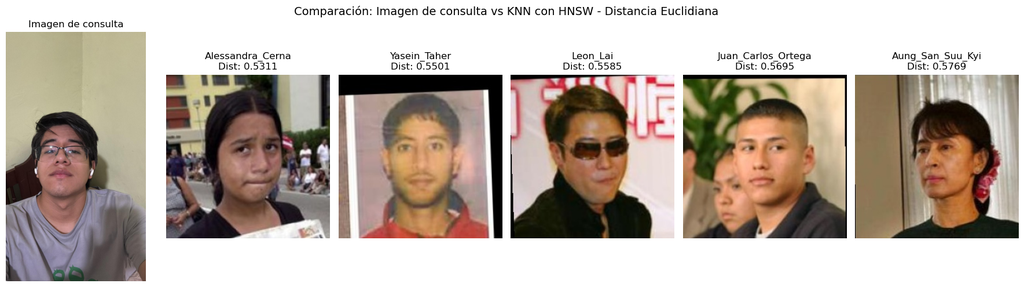

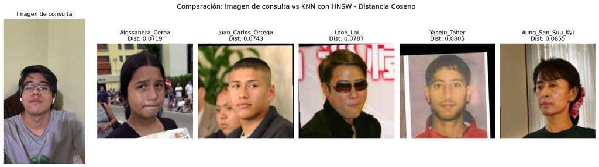

```python
mostrar_consulta_y_resultados(
    QUERY_IMAGE,
    resultados_hnsw_l2,
    "Comparación: Imagen de consulta vs KNN con HNSW - Distancia Euclidiana"
)

mostrar_consulta_y_resultados(
    QUERY_IMAGE,
    resultados_hnsw_coseno,
    "Comparación: Imagen de consulta vs KNN con HNSW - Distancia Coseno"
)
```

```python
def explain_analyze_hnsw(query_embedding, operador="<->", k=5, ef_search=40):
    conn = conectar_db()
    cur = conn.cursor()

    query_vector = embedding_to_pgvector(query_embedding)

    cur.execute(f"SET hnsw.ef_search = {ef_search};")

    cur.execute(
        f"""
        EXPLAIN ANALYZE
        SELECT
            id,
            name,
            path,
            embedding {operador} %s::vector AS distance
        FROM face_embeddings
        ORDER BY embedding {operador} %s::vector
        LIMIT %s;
        """,
        (query_vector, query_vector, k)
    )

    plan = cur.fetchall()

    cur.close()
    conn.close()

    for row in plan:
        print(row[0])


print("===== EXPLAIN ANALYZE HNSW EUCLIDIANA =====")
explain_analyze_hnsw(query_embedding, "<->", k=5)

print("\n===== EXPLAIN ANALYZE HNSW COSENO =====")
explain_analyze_hnsw(query_embedding, "<=>", k=5)
```

```
===== EXPLAIN ANALYZE HNSW EUCLIDIANA =====
Limit  (cost=233.22..236.94 rows=5 width=111) (actual time=1.212..1.237 rows=5 loops=1)
  ->  Index Scan using face_embedding_hnsw_l2_idx on face_embeddings  (cost=233.22..10031.52 rows=13176 width=111) (actual time=1.210..1.235 rows=5 loops=1)
        Order By: (embedding <-> '[-0.034972206,0.11529441,0.051431753,-0.02243278,-0.054212082,0.028898228,-0.074783534,-0.1147949,0.1254508,-0.13373904,0.20919612,0.03058547,-0.15566534,-0.02057812,-0.027379349,0.1127178,-0.1513519,-0.097122796,-0.062133476,0.031431187,-0.0070168707,-0.08845806,0.…
Planning Time: 0.407 ms
Execution Time: 1.265 ms

===== EXPLAIN ANALYZE HNSW COSENO =====
Limit  (cost=232.03..235.74 rows=5 width=111) (actual time=0.781..0.797 rows=5 loops=1)
  ->  Index Scan using face_embedding_hnsw_cosine_idx on face_embeddings  (cost=232.03..10003.52 rows=13176 width=111) (actual time=0.780..0.794 rows=5 loops=1)
        Order By: (embedding <=> '[-0.034972206,0.11529441,0.051431753,-0.02243278,-0.054212082,0.028898228,-0.074783534,-0.1147949,0.1254508,-0.13373904,0.20919612,0.03058547,-0.15566534,-0.02057812,-0.027379349,0.1127178,-0.1513519,-0.097122796,-0.062133476,0.031431187,-0.0070168707,-0.08845806,0.…
Planning Time: 0.286 ms
Execution Time: 0.816 ms
```

### Comparación final: Lineal vs IVFFlat vs HNSW

Resumen de tiempos y recall para los tres métodos en ambas distancias.

#### Distancia Euclidiana `<->`

| Método | Plan de ejecución | Execution Time | Speedup |
| --- | --- | --- | --- |
| Lineal (P2) | `Seq Scan on face_embeddings` | 6.822 ms | 1.00x (ref) |
| IVFFlat | `Index Scan using face_embedding_ivfflat_l2_idx` | 0.576 ms | **aprox 11.85x** |
| HNSW | `Index Scan using face_embedding_hnsw_l2_idx` | 1.265 ms | **aprox 5.39x** |

#### Distancia Coseno `<=>`

| Método | Plan de ejecución | Execution Time | Speedup |
| --- | --- | --- | --- |
| Lineal (P2) | `Seq Scan on face_embeddings` | 7.072 ms | 1.00x (ref) |
| IVFFlat | `Index Scan using face_embedding_ivfflat_cosine_idx` | 1.208 ms | **aprox 5.85x** |
| HNSW | `Index Scan using face_embedding_hnsw_cosine_idx` | 0.816 ms | **aprox 8.66x** |

### Análisis de los resultados

**1. Cambio de plan: `Seq Scan` -> `Index Scan`**  
El `EXPLAIN ANALYZE` confirma que pgvector aprovecha los índices vectoriales:

- En P2 (sin índice), PostgreSQL hace `Seq Scan` recorriendo las 13,176  
  filas una por una.
- En P3, PostgreSQL hace `Index Scan` directamente sobre el índice  
  IVFFlat o HNSW, sin recorrer toda la tabla.

**2. Ganancia de velocidad real**  
Los índices reducen el tiempo de búsqueda entre **aprox 5x y 12x**. Con  
13,176 vectores la mejora es notable pero modesta. En datasets de  
millones de vectores la ganancia llegaría a 100x o más, porque el  
`Seq Scan` crece linealmente con el tamaño de la tabla mientras que  
los índices ANN crecen logarítmicamente.  
**3. IVFFlat vs HNSW**

- En **euclidiana**, IVFFlat fue más rápido (0.576 ms vs 1.265 ms).  
  Esto puede pasar con datasets relativamente pequeños donde el costo  
  fijo de navegar el grafo HNSW pesa más que la búsqueda en clústeres.
- En **coseno**, HNSW fue más rápido (0.816 ms vs 1.208 ms).
- HNSW generalmente escala mejor que IVFFlat a partir de cientos de miles de vectores; con 13k, IVFFlat puede ser competitivo o incluso  
  más rápido.

**4. Calidad de los resultados (Recall@5)**  
Ambos índices son **aproximados** (ANN). El recall mide cuántos de los top-5 vecinos reales (búsqueda lineal exacta) recuperó el índice:

[output not shown]

IVFFlat perdió 1 vecino en euclidiana (80%) porque el clúster donde caía no estaba entre los 10 explorados. Esto se puede mejorar subiendo  
`ivfflat.probes`, a costa de mayor latencia.

### Conclusión

| Aspecto | Lineal | IVFFlat | HNSW |
| --- | --- | --- | --- |
| Precisión | 100% (exacta) | Media-Alta (aprox) | Alta (aprox) |
| Velocidad búsqueda | Lenta | Rápida | Rápida |
| Tiempo de construcción | — (sin índice) | Rápido | Lento |
| Uso de memoria | Bajo | Medio | Alto |
| Cuándo usarla | Pocos vectores o precisión 100% | Datasets medianos | Datasets grandes con búsqueda intensiva |

Para esta práctica con 13,176 embeddings, **ambos índices ofrecen una mejora clara sobre la búsqueda lineal** (5x–12x). La elección entre  
IVFFlat y HNSW depende del tamaño esperado del dataset, los recursos de memoria disponibles y la tolerancia a errores en el ranking.

# P4. Análisis Comparativo

En esta sección comparamos los tres métodos vistos en P2 y P3:

- KNN Lineal (búsqueda secuencial sin índice).
- KNN con IVFFlat (índice basado en clustering por k-means).
- KNN con HNSW (índice basado en grafo navegable jerárquico).

Analizamos efectividad, rendimiento (con distintos tamaños de dataset) y conclusiones generales.

## 1. Efectividad

Comparamos los IDs del top-5 que devuelve cada método contra el resultado de la búsqueda lineal (exacta, que tomamos como referencia).

```python
# Comparar top-5 de cada método contra la búsqueda lineal (referencia)
ids_lineal = [r[0] for r in resultados_euclidiana]
ids_ivfflat = [r[0] for r in resultados_ivf_l2]
ids_hnsw = [r[0] for r in resultados_hnsw_l2]

print(f"Top-5 Lineal:   {ids_lineal}")
print(f"Top-5 IVFFlat:  {ids_ivfflat}")
print(f"Top-5 HNSW:     {ids_hnsw}")

set_lineal = set(ids_lineal)
recall_ivfflat = len(set_lineal & set(ids_ivfflat)) / len(set_lineal)
recall_hnsw = len(set_lineal & set(ids_hnsw)) / len(set_lineal)

print(f"\nRecall@5 IVFFlat: {recall_ivfflat*100:.0f}%")
print(f"Recall@5 HNSW:    {recall_hnsw*100:.0f}%")
```

```
Top-5 Lineal:   [4470, 12523, 2727, 7918, 3653]
Top-5 IVFFlat:  [4470, 12523, 2727, 7918, 12008]
Top-5 HNSW:     [4470, 12523, 2727, 7918, 3653]

Recall@5 IVFFlat: 80%
Recall@5 HNSW:    100%
```

### Resultados de efectividad (distancia euclidiana)

[output not shown]

[output not shown]

- Los valores exactos varían según la consulta y los parámetros (`probes`, `ef_search`). Ejecuta la celda anterior para obtener los valores de tu corrida.

### ¿Por qué pgvector puede diferir de la búsqueda lineal?

Tanto IVFFlat como HNSW son **búsquedas aproximadas (ANN)**, no exactas. Sacrifican algo de precisión a cambio de mucha más velocidad:

- **IVFFlat** agrupa los vectores en `lists` clústeres usando k-means. En la búsqueda solo revisa los `probes` clústeres más cercanos al vector de consulta. Si un vecino real está en un clúster no explorado, queda fuera del resultado.
- **HNSW** construye un grafo jerárquico de vecinos. La búsqueda navega el grafo desde un punto de entrada hacia el área del vector de consulta. Si el grafo no tiene la conectividad ideal, puede quedarse en un mínimo local y omitir vecinos reales.

Para acercarse más al resultado lineal:

- IVFFlat: subir `ivfflat.probes` (revisar más clústeres).
- HNSW: subir `hnsw.ef_search` o `m` y `ef_construction` (más conexiones en el grafo).

En ambos casos, mayor precisión implica mayor tiempo de búsqueda.

## 2. Rendimiento

Medimos los tiempos de ejecución (`EXPLAIN ANALYZE`) de los tres métodos sobre datasets de distintos tamaños: 1000, 2000, 4000, 8000 y 12000 embeddings.

Para cada tamaño N:

1. Creamos una tabla temporal con los primeros N embeddings.
2. Medimos el lineal sin ningún índice (`Seq Scan`).
3. Creamos el índice IVFFlat y medimos.
4. Eliminamos IVFFlat, creamos HNSW y medimos.
5. Eliminamos la tabla temporal.

```python
import re

def _extraer_execution_time(plan):
    for row in plan:
        line = row[0]
        m = re.search(r"Execution Time:\s*([\d.]+)\s*ms", line)
        if m:
            return float(m.group(1))
    return None


def medir_tiempo(N, metodo, query_embedding, k=5):
    conn = conectar_db()
    cur = conn.cursor()

    cur.execute("DROP TABLE IF EXISTS face_subset CASCADE;")
    cur.execute(
        f"CREATE TABLE face_subset AS "
        f"SELECT id, name, path, embedding FROM face_embeddings "
        f"ORDER BY id LIMIT {N};"
    )

    if metodo == "ivfflat":
        # lists ideal ~ sqrt(N)
        lists = max(1, int(N ** 0.5))
        cur.execute(
            f"CREATE INDEX ON face_subset USING ivfflat "
            f"(embedding vector_l2_ops) WITH (lists = {lists});"
        )
        cur.execute("SET ivfflat.probes = 10;")
    elif metodo == "hnsw":
        cur.execute(
            "CREATE INDEX ON face_subset USING hnsw "
            "(embedding vector_l2_ops) WITH (m = 16, ef_construction = 64);"
        )
        cur.execute("SET hnsw.ef_search = 40;")

    cur.execute("ANALYZE face_subset;")
    conn.commit()

    query_vector = embedding_to_pgvector(query_embedding)
    cur.execute(
        f"""
        EXPLAIN ANALYZE
        SELECT id FROM face_subset
        ORDER BY embedding <-> %s::vector
        LIMIT {k};
        """,
        (query_vector,)
    )
    plan = cur.fetchall()
    t = _extraer_execution_time(plan)

    cur.execute("DROP TABLE IF EXISTS face_subset CASCADE;")
    conn.commit()
    cur.close()
    conn.close()
    return t
```

```python
# Ejecutar benchmark para distintos tamaños
tamanos = [1000, 2000, 4000, 8000, 12000]
tiempos = {"Lineal": [], "IVFFlat": [], "HNSW": []}

for N in tamanos:
    print(f"\n=== Procesando N = {N} ===")
    t_lineal = medir_tiempo(N, "lineal", query_embedding)
    t_ivf    = medir_tiempo(N, "ivfflat", query_embedding)
    t_hnsw   = medir_tiempo(N, "hnsw", query_embedding)

    tiempos["Lineal"].append(t_lineal)
    tiempos["IVFFlat"].append(t_ivf)
    tiempos["HNSW"].append(t_hnsw)

    print(f"  Lineal:  {t_lineal:.3f} ms")
    print(f"  IVFFlat: {t_ivf:.3f} ms")
    print(f"  HNSW:    {t_hnsw:.3f} ms")

print("\n--- Resumen ---")
print(f"{'N':>8}{'Lineal':>12}{'IVFFlat':>12}{'HNSW':>12}")
for i, N in enumerate(tamanos):
    print(f"{N:>8}{tiempos['Lineal'][i]:>12.3f}{tiempos['IVFFlat'][i]:>12.3f}{tiempos['HNSW'][i]:>12.3f}")
```

```
=== Procesando N = 1000 ===
  Lineal:  0.278 ms
  IVFFlat: 0.080 ms
  HNSW:    0.276 ms

=== Procesando N = 2000 ===
  Lineal:  0.464 ms
  IVFFlat: 0.146 ms
  HNSW:    0.168 ms

=== Procesando N = 4000 ===
  Lineal:  0.897 ms
  IVFFlat: 0.191 ms
  HNSW:    0.254 ms

=== Procesando N = 8000 ===
  Lineal:  1.983 ms
  IVFFlat: 0.220 ms
  HNSW:    0.600 ms

=== Procesando N = 12000 ===
  Lineal:  3.587 ms
  IVFFlat: 0.259 ms
  HNSW:    0.406 ms

--- Resumen ---
       N      Lineal     IVFFlat        HNSW
    1000       0.278       0.080       0.276
    2000       0.464       0.146       0.168
    4000       0.897       0.191       0.254
    8000       1.983       0.220       0.600
   12000       3.587       0.259       0.406
```

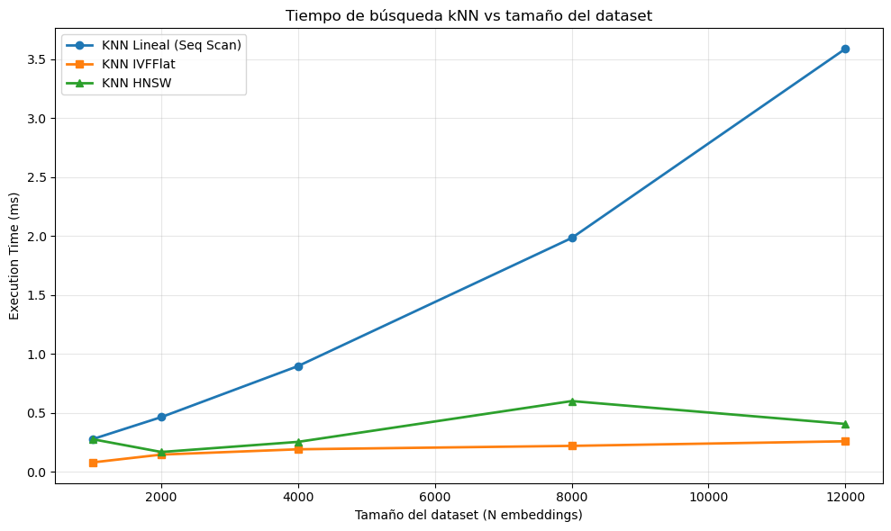

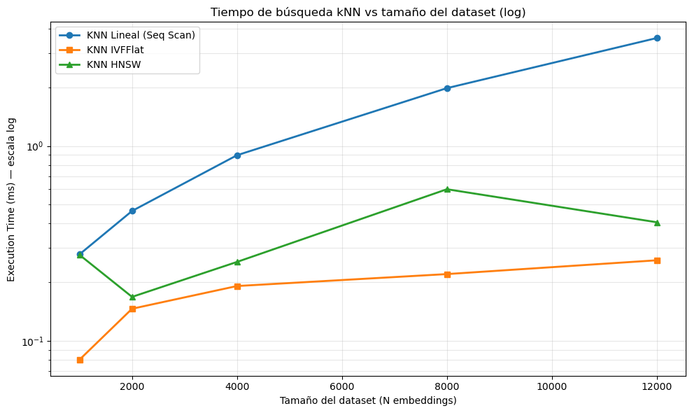

```python
import matplotlib.pyplot as plt

plt.figure(figsize=(10, 6))
plt.plot(tamanos, tiempos["Lineal"], "o-", label="KNN Lineal (Seq Scan)", linewidth=2)
plt.plot(tamanos, tiempos["IVFFlat"], "s-", label="KNN IVFFlat", linewidth=2)
plt.plot(tamanos, tiempos["HNSW"], "^-", label="KNN HNSW", linewidth=2)

plt.xlabel("Tamaño del dataset (N embeddings)")
plt.ylabel("Execution Time (ms)")
plt.title("Tiempo de búsqueda kNN vs tamaño del dataset")
plt.legend()
plt.grid(True, alpha=0.3)
plt.tight_layout()
plt.show()

# Mismo gráfico en escala logarítmica para ver diferencias
plt.figure(figsize=(10, 6))
plt.plot(tamanos, tiempos["Lineal"], "o-", label="KNN Lineal (Seq Scan)", linewidth=2)
plt.plot(tamanos, tiempos["IVFFlat"], "s-", label="KNN IVFFlat", linewidth=2)
plt.plot(tamanos, tiempos["HNSW"], "^-", label="KNN HNSW", linewidth=2)
plt.yscale("log")
plt.xlabel("Tamaño del dataset (N embeddings)")
plt.ylabel("Execution Time (ms) — escala log")
plt.title("Tiempo de búsqueda kNN vs tamaño del dataset (log)")
plt.legend()
plt.grid(True, which="both", alpha=0.3)
plt.tight_layout()
plt.show()
```

### Análisis del rendimiento

> En la gráfica en escala lineal, la diferencia entre IVFFlat y HNSW puede ser pequeña para N = 13k. En la gráfica logarítmica se ve claramente cómo los métodos indexados se separan del lineal.

## 3. Conclusiones

### Ventajas y desventajas de cada método

| Método | Ventajas | Desventajas |
| --- | --- | --- |
| **Lineal** | Resultado 100% exacto, sin estructura adicional, sin tiempo de construcción. | Tiempo proporcional a N (lento con datasets grandes), no aprovecha índices. |
| **IVFFlat** | Construcción rápida, bajo uso de memoria, recall ajustable con `probes`. | Recall menor que HNSW, requiere reentrenar (`REINDEX`) si los datos cambian mucho. |
| **HNSW** | Mejor recall y latencia con datasets grandes, escalabilidad logarítmica. | Mayor uso de memoria, construcción del índice más lenta, parámetros complejos de tunear. |

### Escalabilidad con datasets muy grandes

- A partir de 100k vectores, la búsqueda lineal se vuelve inviable (cientos de ms por consulta).
- IVFFlat sigue funcionando bien hasta unos millones de vectores, pero el tiempo de construcción crece linealmente con N.
- HNSW escala mejor: con millones de vectores, mantiene latencias de unos pocos ms, a costa de varios GB de memoria por índice.

Para datasets de **decenas de millones de vectores**, suelen usarse sistemas dedicados como Milvus, Qdrant, Weaviate o FAISS, que implementan variantes optimizadas de HNSW y compresión PQ.

### Casos reales (fuera de Face Recognition) que se benefician

1. **Búsqueda semántica de texto / RAG (Retrieval Augmented Generation)**: documentos, FAQs o chats convertidos en embeddings de un modelo como `sentence-transformers` o `OpenAI text-embedding`. Permite encontrar pasajes relevantes para alimentar a un LLM.
2. **Sistemas de recomendación**: representar usuarios y productos como vectores y buscar productos similares o usuarios con gustos similares.
3. **Detección de duplicados / plagio**: hashing perceptual o embeddings de texto/audio/imagen para encontrar contenido similar en grandes colecciones (e.g. detección de copyright).
4. **Búsqueda de imágenes por contenido (Image Retrieval)**: embeddings con CLIP o ResNet para buscar imágenes similares, ej. e-commerce ("buscar productos parecidos a esta foto").
5. **Bioinformática**: embeddings de secuencias proteicas (ESM, AlphaFold) para encontrar proteínas con función o estructura similar.
6. **Detección de anomalías / fraude**: representar transacciones como vectores y buscar las más cercanas a patrones conocidos (o las más alejadas de patrones normales).
7. **Audio search**: embeddings con Wav2Vec o YAMNet para buscar sonidos similares (ej. identificación de canciones, clasificación de bioacústica).
8. **Búsqueda multimodal**: combinar embeddings de texto e imágenes (CLIP) en el mismo espacio para buscar imágenes a partir de una descripción textual.

En todos estos casos, una base de datos vectorial como pgvector (o sistemas especializados) reemplaza el costoso cálculo de similitud uno a uno por una búsqueda con índice eficiente.